# 24133064_NguyenThiKieuTrang_LAB4_EDA2

## 3. Làm sạch dữ liệu

### 1. Kiểm tra missing values trong toàn bộ dữ liệu.

```r
colSums(is.na(mpg))
```

```
## manufacturer        model        displ         year          cyl        trans
##            0            0            0            0            0            0
##          drv          cty          hwy           fl        class
##            0            0            0            0            0
```

Dữ liệu không có giá trị thiếu nên không cần xử lý.

### 2. Kiểm tra các nhóm class có số lượng quan sát quá nhỏ.

```r
table(mpg$class)
```

```
##
##    2seater    compact    midsize    minivan     pickup subcompact        suv
##          5         47         41         11         33         35         62
```

### 3. Kiểm tra giá trị bất thường: hwy > 40; hwy < 15; cty > hwy; displ quá lớn hoặc quá nhỏ.

```r
outlier<- mpg %>%
  filter(hwy>40|hwy<15|cty>hwy|displ>7|displ<1
)
outlier
```

```
## # A tibble: 10 × 11
##    manufacturer model      displ  year   cyl trans drv     cty   hwy fl    class
##    <chr>        <chr>      <dbl> <int> <int> <chr> <chr> <int> <int> <chr> <chr>
##  1 chevrolet    k1500 tah…   5.3  2008     8 auto… 4        11    14 e     suv
##  2 dodge        dakota pi…   4.7  2008     8 auto… 4         9    12 e     pick…
##  3 dodge        durango 4…   4.7  2008     8 auto… 4         9    12 e     suv
##  4 dodge        ram 1500 …   4.7  2008     8 auto… 4         9    12 e     pick…
##  5 dodge        ram 1500 …   4.7  2008     8 manu… 4         9    12 e     pick…
##  6 jeep         grand che…   4.7  2008     8 auto… 4         9    12 e     suv
##  7 jeep         grand che…   6.1  2008     8 auto… 4        11    14 p     suv
##  8 volkswagen   jetta        1.9  1999     4 manu… f        33    44 d     comp…
##  9 volkswagen   new beetle   1.9  1999     4 manu… f        35    44 d     subc…
## 10 volkswagen   new beetle   1.9  1999     4 auto… f        29    41 d     subc…
```

### 4. Đề xuất cách xử lý các quan sát bất thường.

- Các quan sát bất thường cần được kiểm tra để xác định có phải lỗi dữ liệu hay không.
- Nếu các giá trị bất thường xuất phát từ lỗi nhập liệu thì nên loại bỏ hoặc thay thế bằng giá trị phù hợp.
- Nếu dữ liệu phản ánh đúng đặc điểm thực tế của xe thì nên giữ lại để đảm bảo tính đại diện của dữ liệu.

### 5. Giải thích có nên loại bỏ outlier hay giữ lại.

Trong bộ dữ liệu mpg, các giá trị bất thường không nhất thiết là lỗi mà có thể phản ánh đặc điểm thực tế của một số loại xe như xe thể thao, SUV hoặc xe động cơ lớn. Vì vậy, quyết định giữ lại các outlier để đảm bảo dữ liệu phản ánh đúng thực tế. Chỉ loại bỏ khi xác định chắc chắn đó là lỗi dữ liệu.

## 4. Câu hỏi

### 1. Loại xe nào tiết kiệm nhiên liệu đường cao tốc nhất?

```r
mpg%>%
  group_by(class)%>%
  summarise(mean_hwy=mean(hwy))%>%
  arrange(desc(mean_hwy))
```

```
## # A tibble: 7 × 2
##   class      mean_hwy
##   <chr>         <dbl>
## 1 compact        28.3
## 2 subcompact     28.1
## 3 midsize        27.3
## 4 2seater        24.8
## 5 minivan        22.4
## 6 suv            18.1
## 7 pickup         16.9
```

### 2. Dung tích động cơ lớn có làm giảm hwy không?

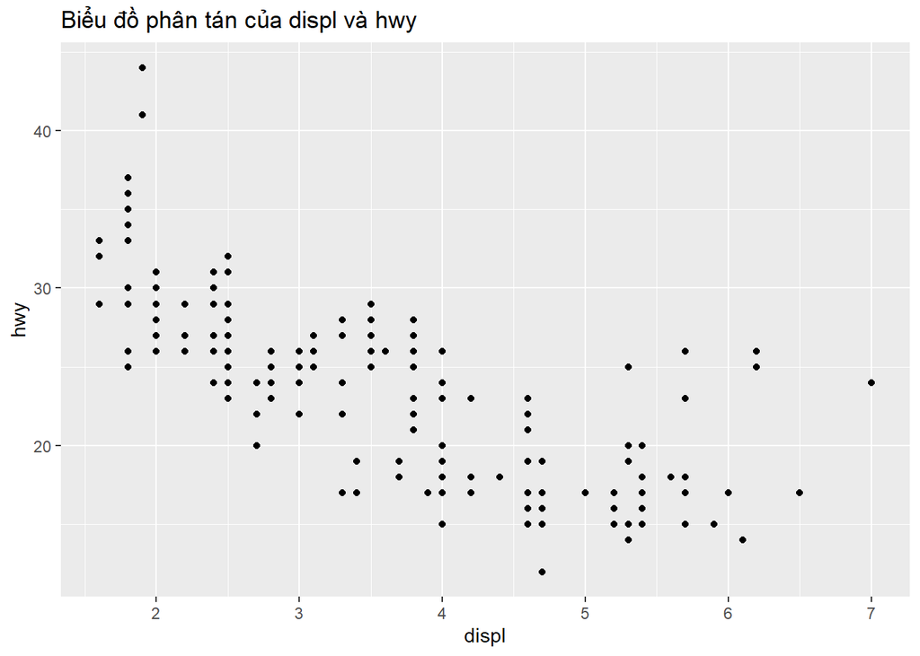

```r
ggplot(mpg, aes(x=displ, y=hwy))+
  geom_point()+
  labs(
    title="Biểu đồ phân tán của displ và hwy",
    x="displ",
    y="hwy"
  )
```

Biểu đồ cho thấy khi dung tích động cơ (displ) tăng thì mức tiết kiệm nhiên liệu trên đường cao tốc (hwy) có xu hướng giảm. Điều này cho thấy xe có động cơ lớn thường tiêu thụ nhiên liệu nhiều hơn.

### 3. Xe dẫn động nào có hiệu quả nhiên liệu tốt hơn?

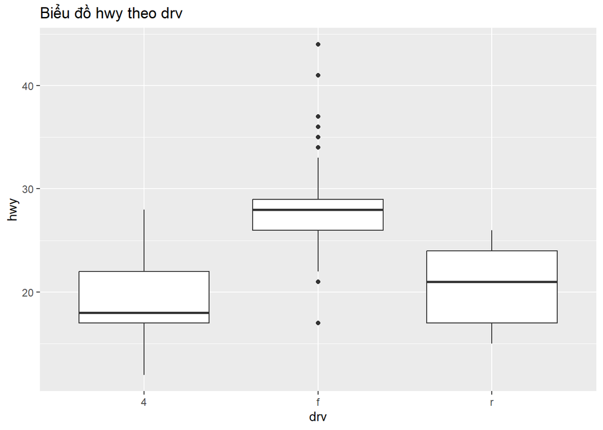

```r
ggplot(mpg, aes(x=drv, y=hwy))+
  geom_boxplot()+
  labs(
    title="Biểu đồ hwy theo drv"
  )
```

Xe dẫn động cầu trước (f) có hiệu quả nhiên liệu tốt hơn so với xe dẫn động bốn bánh (4) hoặc cầu sau (r). Điều này có thể do các xe cầu trước thường nhẹ và có động cơ nhỏ hơn.

### 4. Có nhóm xe nào đi ngược xu hướng chung không?

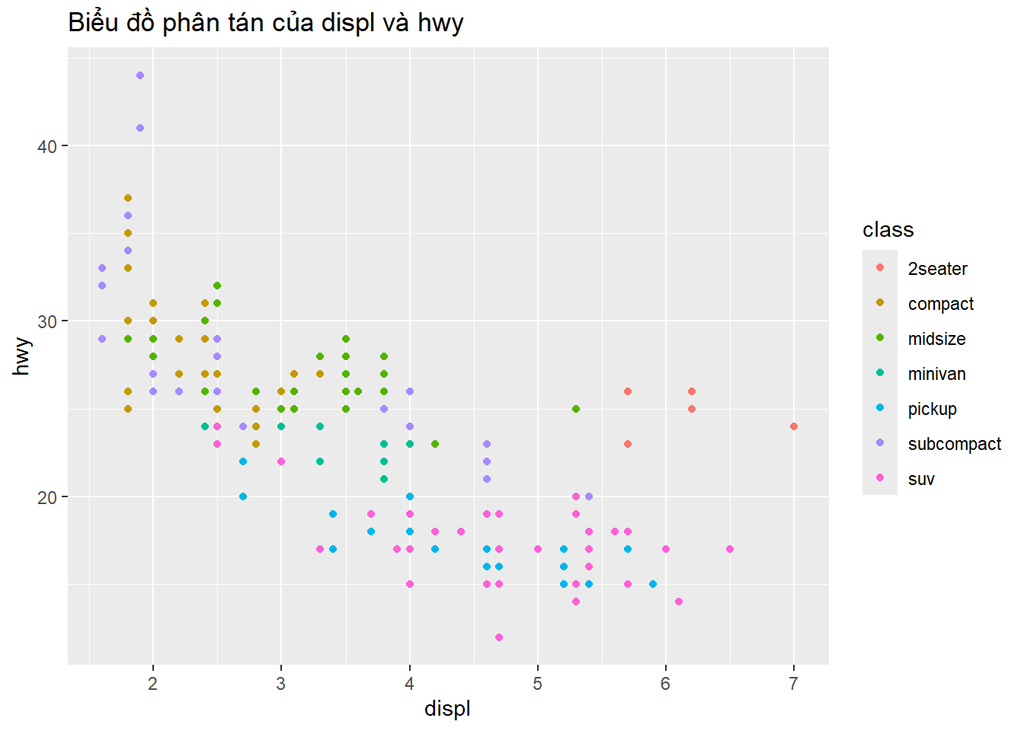

```r
ggplot(mpg, aes(x=displ, y=hwy, color=class))+
  geom_point()+
  labs(
    title="Biểu đồ phân tán của displ và hwy",
    x="displ",
    y="hwy"
  )
```

Xu hướng chung cho thấy dung tích động cơ tăng thì hwy giảm. Tuy nhiên vẫn tồn tại một số xe có dung tích động cơ khá lớn nhưng hwy vẫn cao hoặc xe động cơ nhỏ nhưng hwy thấp. Đây là các nhóm đi ngược xu hướng chung.(2seater, midsize)

### 5. Nếu người tiêu dùng ưu tiên tiết kiệm nhiên liệu, nên chọn nhóm xe nào?

Nếu người tiêu dùng ưu tiên tiết kiệm nhiên liệu thì nên chọn các dòng xe nhỏ như compact hoặc subcompact, đặc biệt là xe dẫn động cầu trước (f). Các dòng xe này thường có động cơ nhỏ hơn và mức tiêu thụ nhiên liệu thấp hơn so với SUV hoặc xe động cơ lớn.

*Khuyến nghị cho người tiêu dùng:*

Nếu mục tiêu là tiết kiệm nhiên liệu, người tiêu dùng nên ưu tiên các dòng xe nhỏ như compact hoặc subcompact vì chúng thường có động cơ nhỏ hơn và mức tiêu thụ nhiên liệu thấp hơn. Xe dẫn động cầu trước (f) cũng là lựa chọn hợp lý vì thường nhẹ và hiệu quả nhiên liệu tốt hơn so với xe dẫn động cầu sau (r) hoặc 4 bánh (4). Ngoài ra, khi chọn xe, nên kết hợp xem xét dung tích động cơ, loại dẫn động và trọng lượng xe để đảm bảo lựa chọn phù hợp với nhu cầu di chuyển và tiết kiệm chi phí nhiên liệu lâu dài.

# III.Dữ liệu: starwars

## Một nhóm sản xuất nội dung muốn phân tích đặc điểm nhân vật trong Star Wars để xây dựng infographic về chiều cao, cân nặng, giới tính, loài và đặc điểm ngoại hình của các nhân vật.

## Yêu cầu: Sinh viên đóng vai trò là data analyst cho nhóm truyền thông dữ liệu.

## 1. Phân tích dữ liệu

```r
data("starwars")
```

### 1. Mô tả cấu trúc dữ liệu starwars.

#### Số dòng

```r
nrow(starwars)
```

```
## [1] 87
```

#### Số cột

```r
ncol(starwars)
```

```
## [1] 14
```

#### Kiểu dữ liệu

```r
str(starwars)
```

```
## tibble [87 × 14] (S3: tbl_df/tbl/data.frame)
##  $ name      : chr [1:87] "Luke Skywalker" "C-3PO" "R2-D2" "Darth Vader" ...
##  $ height    : int [1:87] 172 167 96 202 150 178 165 97 183 182 ...
##  $ mass      : num [1:87] 77 75 32 136 49 120 75 32 84 77 ...
##  $ hair_color: chr [1:87] "blond" NA NA "none" ...
##  $ skin_color: chr [1:87] "fair" "gold" "white, blue" "white" ...
##  $ eye_color : chr [1:87] "blue" "yellow" "red" "yellow" ...
##  $ birth_year: num [1:87] 19 112 33 41.9 19 52 47 NA 24 57 ...
##  $ sex       : chr [1:87] "male" "none" "none" "male" ...
##  $ gender    : chr [1:87] "masculine" "masculine" "masculine" "masculine" ...
##  $ homeworld : chr [1:87] "Tatooine" "Tatooine" "Naboo" "Tatooine" ...
##  $ species   : chr [1:87] "Human" "Droid" "Droid" "Human" ...
##  $ films     :List of 87
##   ..$ : chr [1:5] "A New Hope" "The Empire Strikes Back" "Return of the Jedi" "Revenge of the Sith" ...
##   ..$ : chr [1:6] "A New Hope" "The Empire Strikes Back" "Return of the Jedi" "The Phantom Menace" ...
##   ..$ : chr [1:7] "A New Hope" "The Empire Strikes Back" "Return of the Jedi" "The Phantom Menace" ...
##   ..$ : chr [1:4] "A New Hope" "The Empire Strikes Back" "Return of the Jedi" "Revenge of the Sith"
##   ..$ : chr [1:5] "A New Hope" "The Empire Strikes Back" "Return of the Jedi" "Revenge of the Sith" ...
##   ..$ : chr [1:3] "A New Hope" "Attack of the Clones" "Revenge of the Sith"
##   ..$ : chr [1:3] "A New Hope" "Attack of the Clones" "Revenge of the Sith"
##   ..$ : chr "A New Hope"
##   ..$ : chr "A New Hope"
##   ..$ : chr [1:6] "A New Hope" "The Empire Strikes Back" "Return of the Jedi" "The Phantom Menace" ...
##   ..$ : chr [1:3] "The Phantom Menace" "Attack of the Clones" "Revenge of the Sith"
##   ..$ : chr [1:2] "A New Hope" "Revenge of the Sith"
##   ..$ : chr [1:5] "A New Hope" "The Empire Strikes Back" "Return of the Jedi" "Revenge of the Sith" ...
##   ..$ : chr [1:4] "A New Hope" "The Empire Strikes Back" "Return of the Jedi" "The Force Awakens"
##   ..$ : chr "A New Hope"
##   ..$ : chr [1:3] "A New Hope" "Return of the Jedi" "The Phantom Menace"
##   ..$ : chr [1:3] "A New Hope" "The Empire Strikes Back" "Return of the Jedi"
##   ..$ : chr "A New Hope"
##   ..$ : chr [1:5] "The Empire Strikes Back" "Return of the Jedi" "The Phantom Menace" "Attack of the Clones" ...
##   ..$ : chr [1:5] "The Empire Strikes Back" "Return of the Jedi" "The Phantom Menace" "Attack of the Clones" ...
##   ..$ : chr [1:3] "The Empire Strikes Back" "Return of the Jedi" "Attack of the Clones"
##   ..$ : chr "The Empire Strikes Back"
##   ..$ : chr "The Empire Strikes Back"
##   ..$ : chr [1:2] "The Empire Strikes Back" "Return of the Jedi"
##   ..$ : chr "The Empire Strikes Back"
##   ..$ : chr [1:2] "Return of the Jedi" "The Force Awakens"
##   ..$ : chr "Return of the Jedi"
```

[output cut: 221 more lines]

```
##   ..$ : chr(0)
##   ..$ : chr(0)
##   ..$ : chr(0)
##   ..$ : chr(0)
##   ..$ : chr(0)
##   ..$ : chr "Belbullab-22 starfighter"
##   ..$ : chr(0)
##   ..$ : chr(0)
##   ..$ : chr(0)
##   ..$ : chr(0)
##   ..$ : chr(0)
##   ..$ : chr(0)
##   ..$ : chr "X-wing"
##   ..$ : chr(0)
##   ..$ : chr(0)
```

Dữ liệu starwars gồm thông tin về các nhân vật như chiều cao, cân nặng, năm sinh, giới tính, loài, quê nhà và đặc điểm ngoại hình.

### 2. Xác định biến định lượng: height; mass; birth_year.

```r
quantitative_vars <- c("height", "mass", "birth_yea")
quantitative_vars
```

```
## [1] "height"    "mass"      "birth_yea"
```

### 3. Xác định biến phân loại: sex; gender; species; homeworld; hair_color; eye_color; skin_color.

```r
categorical3_vars <- c("sex","gender","species","homeworld"," hair_color","eye_color","skin_color")
categorical3_vars
```

```
## [1] "sex"         "gender"      "species"     "homeworld"   " hair_color"
## [6] "eye_color"   "skin_color"
```

### 4. Kiểm tra missing values trong từng biến.

```r
colSums(is.na(starwars))
```

```
##       name     height       mass hair_color skin_color  eye_color birth_year
##          0          6         28          5          0          0         44
##        sex     gender  homeworld    species      films   vehicles  starships
##          4          4         10          4          0          0          0
```

```r
starwars %>%
  summarise(
    missing_height = sum(is.na(height)),
    missing_mass = sum(is.na(mass)),
    missing_birth_year = sum(is.na(birth_year)),
    missing_gender = sum(is.na(gender)),
    missing_species = sum(is.na(species))
  )
```

```
## # A tibble: 1 × 5
##   missing_height missing_mass missing_birth_year missing_gender missing_species
##            <int>        <int>              <int>          <int>           <int>
## 1              6           28                 44              4               4
```

### 5. Tạo bảng tần suất cho gender, species, hair_color.

```r
table(starwars$gender)
```

```
##
##  feminine masculine
##        17        66
```

```r
table(starwars$species)
```

```
##
##         Aleena       Besalisk         Cerean       Chagrian       Clawdite
##              1              1              1              1              1
##          Droid            Dug           Ewok      Geonosian         Gungan
##              6              1              1              1              3
##          Human           Hutt       Iktotchi        Kaleesh       Kaminoan
##             35              1              1              1              2
##        Kel Dor       Mirialan   Mon Calamari           Muun       Nautolan
##              1              2              1              1              1
##      Neimodian         Pau'an       Quermian         Rodian        Skakoan
##              1              1              1              1              1
##      Sullustan     Tholothian        Togruta          Toong      Toydarian
##              1              1              1              1              1
##     Trandoshan        Twi'lek     Vulptereen        Wookiee          Xexto
##              1              2              1              2              1
## Yoda's species         Zabrak
##              1              2
```

```r
table(starwars$hair_color)
```

```
##
##        auburn  auburn, grey auburn, white         black         blond
##             1             1             1            13             3
##        blonde         brown   brown, grey          grey          none
##             1            18             1             1            38
##         white
##             4
```

```r
starwars %>%
  count(gender, sort = TRUE)
```

```
## # A tibble: 3 × 2
##   gender        n
##   <chr>     <int>
## 1 masculine    66
## 2 feminine     17
## 3 <NA>          4
```

```r
starwars %>%
  count(species, sort = TRUE)
```

```
## # A tibble: 38 × 2
##    species      n
##    <chr>    <int>
##  1 Human       35
##  2 Droid        6
##  3 <NA>         4
##  4 Gungan       3
##  5 Kaminoan     2
##  6 Mirialan     2
##  7 Twi'lek      2
##  8 Wookiee      2
##  9 Zabrak       2
## 10 Aleena       1
## # ℹ 28 more rows
```

```r
starwars %>%
  count(hair_color, sort = TRUE)
```

```
## # A tibble: 12 × 2
##    hair_color        n
##    <chr>         <int>
##  1 none             38
##  2 brown            18
##  3 black            13
##  4 <NA>              5
##  5 white             4
##  6 blond             3
##  7 auburn            1
##  8 auburn, grey      1
##  9 auburn, white     1
## 10 blonde            1
## 11 brown, grey       1
## 12 grey              1
```

### 6. Tính thống kê mô tả cho height và mass.

```r
summary(starwars[, c("height", "mass")])
```

```
##      height           mass
##  Min.   : 66.0   Min.   :  15.00
##  1st Qu.:167.0   1st Qu.:  55.60
##  Median :180.0   Median :  79.00
##  Mean   :174.6   Mean   :  97.31
##  3rd Qu.:191.0   3rd Qu.:  84.50
##  Max.   :264.0   Max.   :1358.00
##  NAs    :6       NAs    :28
```

## 2. Trực quan hóa dữ liệu

###1. Histogram cho height.

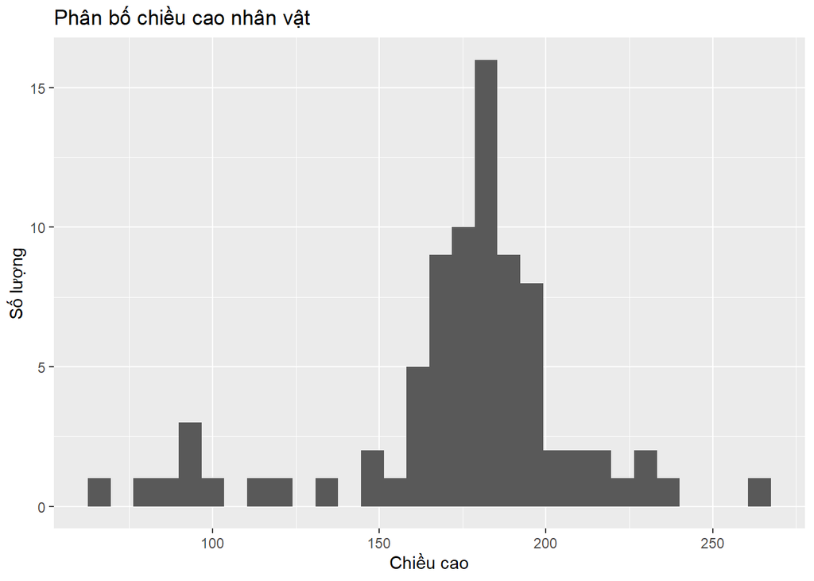

```r
ggplot(starwars, aes(x = height)) +
  geom_histogram() +
  labs(
    title = "Phân bố chiều cao nhân vật",
    x = "Chiều cao",
    y = "Số lượng"
  )
```

Biểu đồ histogram cho thấy dữ liệu chiều cao phân bố theo dạng chuẩn (hình chuông) nhưng có xu hướng lệch nhẹ và xuất hiện các giá trị dị biệt ở cả hai phía. Chiều cao của các nhân vật tập trung phổ biến nhất ở khoảng 170cm – 190cm (với đỉnh cao nhất đạt trên 15 nhân vật ở mốc ~180cm). Xuất hiện một nhóm nhỏ nhân vật có chiều cao cực thấp (dưới 100cm) và một nhân vật cá biệt có chiều cao vượt trội (trên 250cm).

### 2. Histogram cho mass.

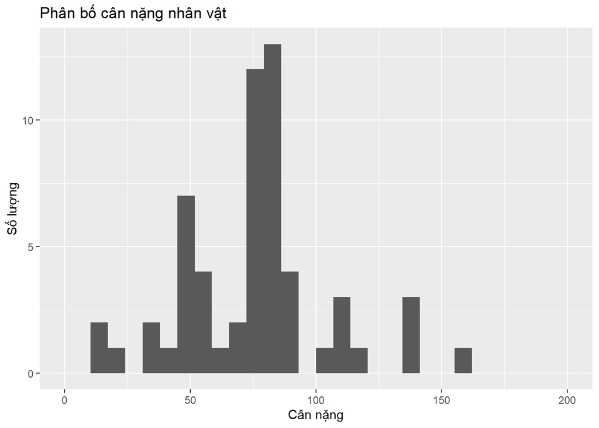

```r
ggplot(starwars, aes(x = mass)) +
  geom_histogram() +
  xlim(0,200)+
  labs(
    title = "Phân bố cân nặng nhân vật",
    x = "Cân nặng",
    y = "Số lượng"
  )
```

Đỉnh tập trung đông nhất: Cân nặng của các nhân vật tập trung nhiều nhất ở khoảng 70kg – 90kg (với cột cao nhất đạt gần 13 nhân vật ở mốc ~80kg, đây là mức cân nặng chuẩn của người trưởng thành). Có một nhóm nhỏ nhân vật nhẹ cân tập trung ở mốc 50kg (như các robot nhỏ hoặc nhân vật nữ). Đa số các nhân vật có cân nặng thực tế nằm trong khoảng từ 50kg đến 100kg.

### 3. Density plot cho height.

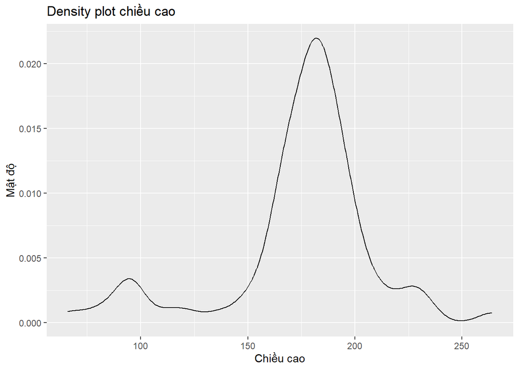

```r
ggplot(starwars, aes(x = height)) +
  geom_density(na.rm = TRUE) +
  labs(
    title = "Density plot chiều cao",
    x = "Chiều cao",
    y = "Mật độ"
  )
```

Biểu đồ mật độ cho thấy dữ liệu chiều cao có phân phối đơn đỉnh rõ rệt ở trung tâm, đi kèm hai cụm nhỏ ở hai đầu rìa dữ liệu. Mật độ nhân vật tập trung cao nhất và dày đặc nhất xung quanh mốc 180cm. Phản ánh rõ sự xuất hiện của hai nhóm nhân vật đặc biệt trong tập dữ liệu: nhóm nhân vật tí hon (dưới 100cm) và nhóm nhân vật khổng lồ (trên 220cm).

### 4. Boxplot cho height.

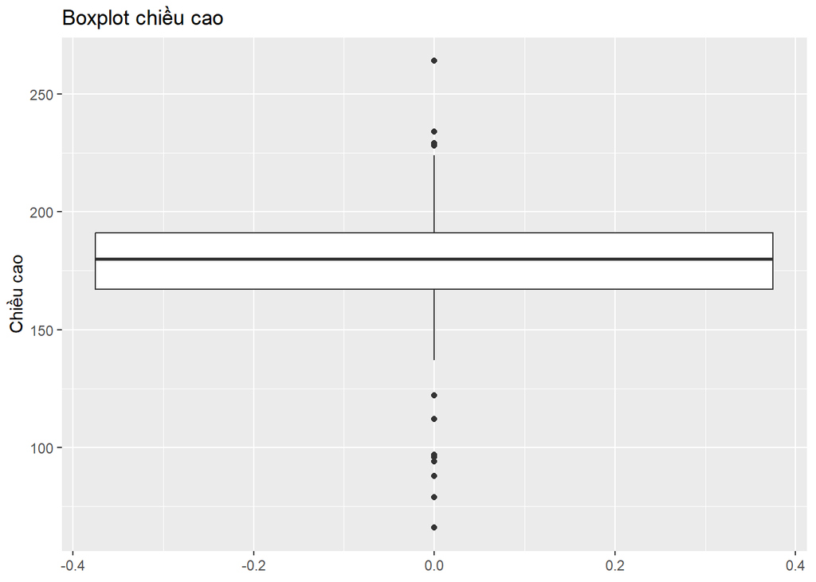

```r
ggplot(starwars, aes(y = height)) +
  geom_boxplot() +
  labs(
    title = "Boxplot chiều cao",
    y = "Chiều cao"
  )
```

Chiều cao trung vị của các nhân vật đạt khoảng 180 cm. Phần lớn các nhân vật (50% dữ liệu ở giữa) có chiều cao dao động ổn định trong khoảng từ 167 cm đến 191 cm. Biểu đồ hộp ghi nhận rất nhiều giá trị dị biệt xuất hiện ở cả hai phía: Nhóm dị biệt phía trên đại diện cho các nhân vật có chiều cao đột biến (trên 225 cm), Nhóm dị biệt phía dưới đại diện cho các nhân vật có kích thước siêu nhỏ (dưới 125 cm).

### 5. Boxplot cho mass.

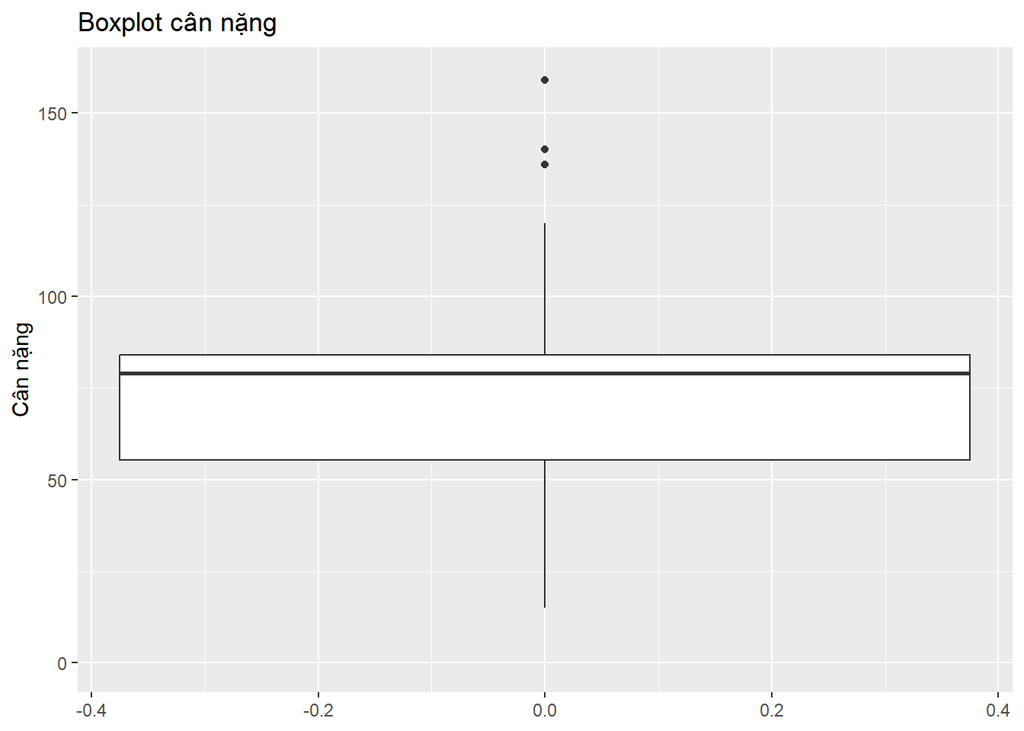

```r
ggplot(starwars, aes(y = mass)) +
  geom_boxplot() +
  ylim(0, 160) +
  labs(
    title = "Boxplot cân nặng",
    y = "Cân nặng"
  )
```

### 6. Bar chart cho gender.

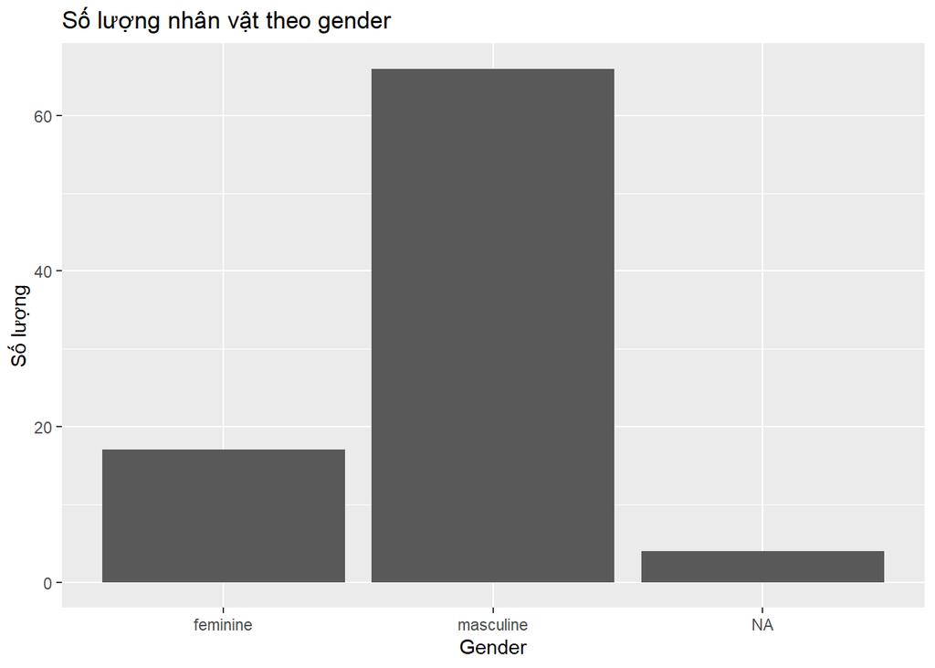

```r
ggplot(starwars, aes(x = gender)) +
  geom_bar() +
  labs(
    title = "Số lượng nhân vật theo gender",
    x = "Gender",
    y = "Số lượng"
  )
```

Masculine (nam giới) chiếm số lượng nhiều nhấ, Vọt lên mức gần 70 nhân vật. Feminine ( nữ giới) nằm ở mức gần 20 nhân vật Một số ít nhân vật còn lại không xác định được giới tính (bị khuyết dữ liệu - NA).

### 7. Bar chart cho species, chỉ giữ nhóm có từ 2 quan sát trở lên.

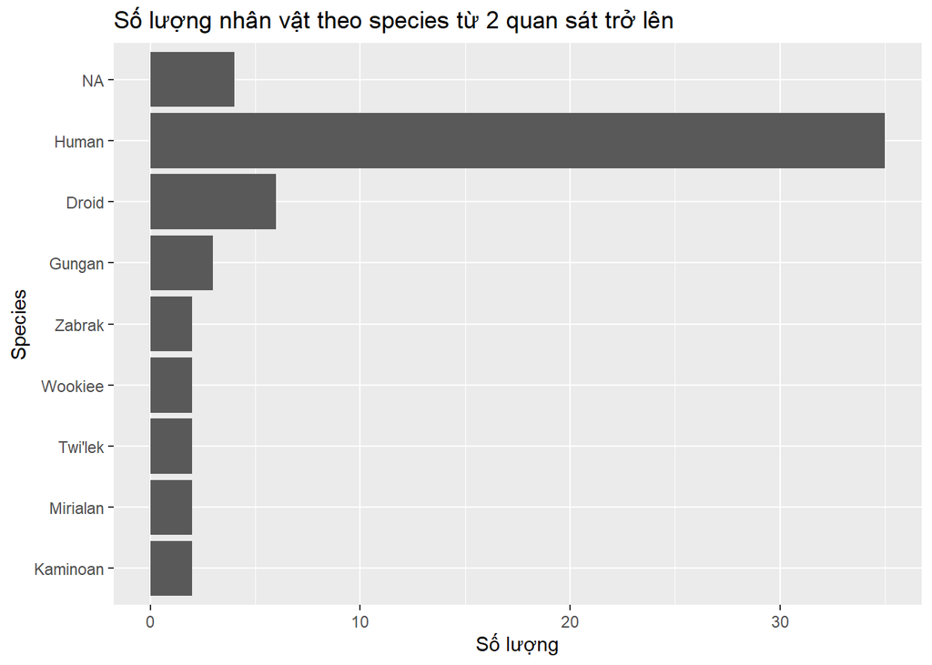

```r
species_2 <- starwars %>%
  count(species) %>%
  filter(n >= 2)

ggplot(species_2, aes(x = reorder(species, n), y = n)) +
  geom_col() +
  coord_flip() +
  labs(
    title = "Số lượng nhân vật theo species từ 2 quan sát trở lên",
    x = "Species",
    y = "Số lượng"
  )
```

Biểu đồ sau khi lọc các chủng tộc có từ 2 cá thể trở lên cho thấy sự chênh lệch rất lớn về mặt phân bố loài trong vũ trụ Star Wars. Chủng tộc con người (Human) chiếm số lượng đông đảo và áp đảo nhất với 35 nhân vật. Người máy (Droid) là nhóm phổ biến thứ hai nhưng số lượng ít hơn nhiều (6 nhân vật). Các chủng tộc còn lại như Gungan, Wookiee, Zabrak… xuất hiện với số lượng rất khiêm tốn, chỉ từ 2 đến 3 cá thể cho mỗi loài. Tập dữ liệu chủ yếu tập trung vào các nhân vật thuộc chủng tộc con người, các loài sinh vật và quái vật ngoài hành tinh đóng vai trò đa dạng sinh học bổ trợ với số lượng nhỏ.

### 8. Boxplot height theo gender.

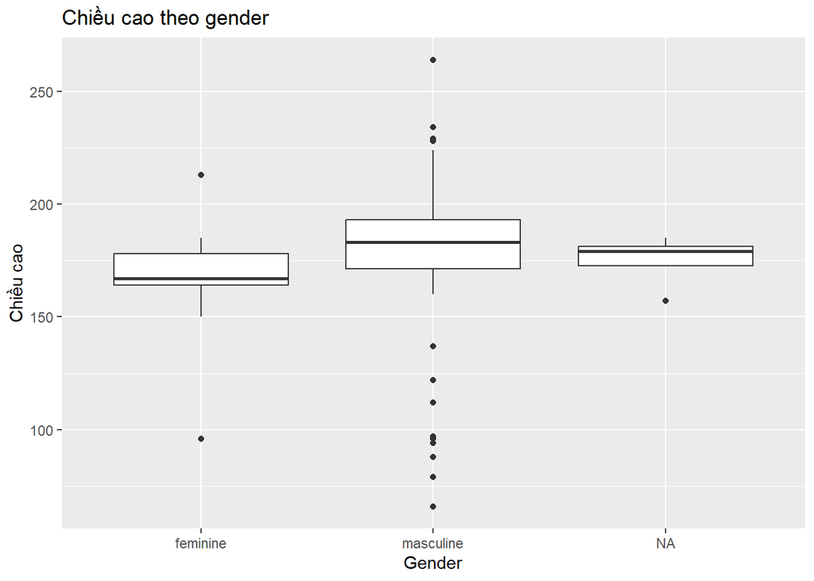

```r
ggplot(starwars, aes(x = gender, y = height)) +
  geom_boxplot() +
  labs(
    title = "Chiều cao theo gender",
    x = "Gender",
    y = "Chiều cao"
  )
```

Biểu đồ hộp cho thấy có sự chênh lệch về chiều cao giữa các nhóm giới tính. Nhóm nhân vật nam (masculine) có chiều cao trung vị lớn nhất (khoảng 184 cm), cao hơn rõ rệt so với nhóm nhân vật nữ (feminine - khoảng 168 cm). Nhóm masculine cũng là nhóm có nhiều giá trị dị biệt (outliers) nhất, xuất hiện ở cả hai cực (siêu cao trên 250 cm và siêu thấp dưới 100 cm).

### 9. Faceted histogram của height theo gender.

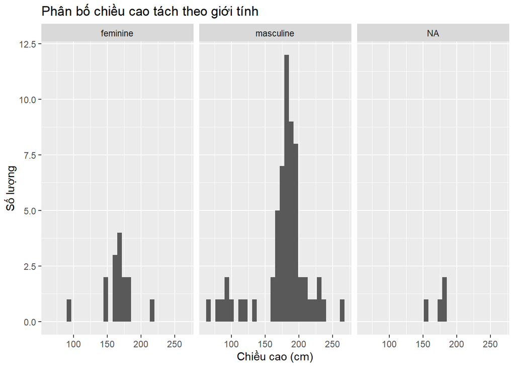

```r
ggplot(starwars, aes(x = height)) +
  geom_histogram() +
  facet_wrap(~ gender) +
  labs(
    title = "Phân bố chiều cao tách theo giới tính",
    x = "Chiều cao (cm)",
    y = "Số lượng"
  )
```

Biểu đồ Facet Histogram cho thấy rõ sự khác biệt về cả số lượng lẫn hình dáng phân bố chiều cao giữa hai giới tính. Nhóm masculine chiếm số lượng áp đảo với ngọn núi dữ liệu cao và rộng, tập trung mạnh ở khoảng 170cm – 190cm. Nhóm này cũng sở hữu dải chiều cao trải dài nhất, bao trọn các cá thể siêu lùn và khổng lồ. Nhóm feminine có số lượng ít hơn nhiều, phân bố hẹp hơn và tập trung ở phân khúc chiều cao thấp hơn, phổ biến từ 160cm – 175cm.

### 10.Scatterplot giữa height và mass.

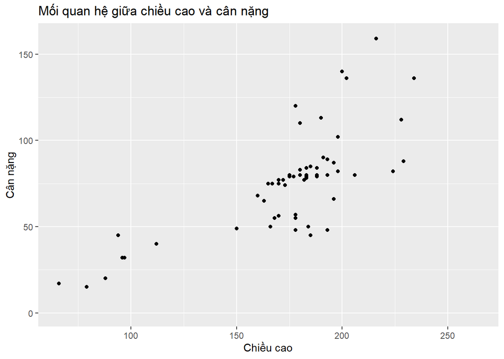

```r
ggplot(starwars, aes(x = height, y = mass)) +
  geom_point() +
  ylim(0, 160) +
  labs(
    title = "Mối quan hệ giữa chiều cao và cân nặng",
    x = "Chiều cao",
    y = "Cân nặng"
  )
```

## 3. Làm sạch dữ liệu

### 1. Kiểm tra missing values trong height, mass, gender, species.

```r
starwars%>%
  summarise(
    missing_height =sum(is.na(height)),
    missing_mass=sum(is.na(mass)),
    missing_gender =sum(is.na(gender)),
    missing_species=sum(is.na(species))
  )
```

```
## # A tibble: 1 × 4
##   missing_height missing_mass missing_gender missing_species
##            <int>        <int>          <int>           <int>
## 1              6           28              4               4
```

### 2. Tạo bảng số lượng missing values cho từng biến.

```r
missing_table <- data.frame(
  variable = names(starwars),
  missing_count=colSums(is.na(starwars))
)
missing_table
```

```
##              variable missing_count
## name             name             0
## height         height             6
## mass             mass            28
## hair_color hair_color             5
## skin_color skin_color             0
## eye_color   eye_color             0
## birth_year birth_year            44
## sex               sex             4
## gender         gender             4
## homeworld   homeworld            10
## species       species             4
## films           films             0
## vehicles     vehicles             0
## starships   starships             0
```

### 3. Phát hiện outlier trong mass, đặc biệt các quan sát có mass > 500.

```r
mass_outlier <- starwars%>%
  filter(mass>500)
mass_outlier
```

```
## # A tibble: 1 × 14
##   name      height  mass hair_color skin_color eye_color birth_year sex   gender
##   <chr>      <int> <dbl> <chr>      <chr>      <chr>          <dbl> <chr> <chr>
## 1 Jabba De…    175  1358 <NA>       green-tan… orange           600 herm… mascu…
## # ℹ 5 more variables: homeworld <chr>, species <chr>, films <list>,
## #   vehicles <list>, starships <list>
```

### 4. Vẽ scatterplot height – mass trước và sau khi loại outlier.

#### Trước khi loại outlier

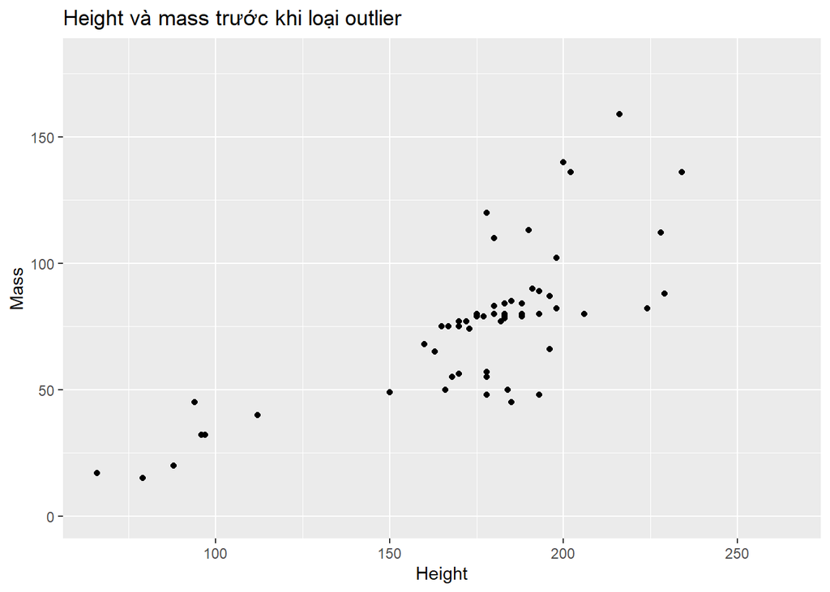

```r
ggplot(starwars, aes(x = height, y = mass)) +
  geom_point() +
  ylim(0,180)+
  labs(
    title = "Height và mass trước khi loại outlier",
    x = "Height",
    y = "Mass"
  )
```

#### Sau khi loại outlier

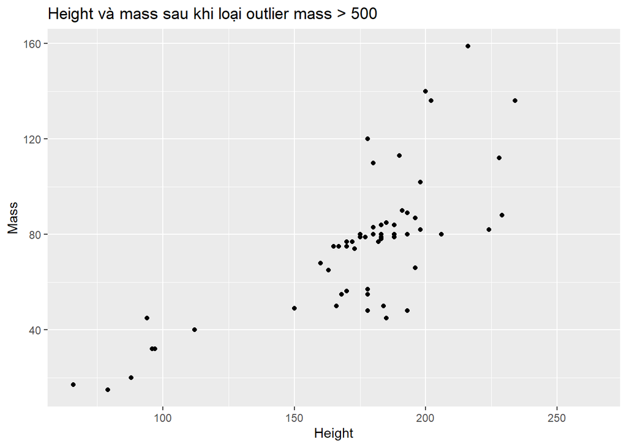

```r
starwars_no_outlier <- starwars %>%
  filter(is.na(mass) | mass <= 500)

ggplot(starwars_no_outlier, aes(x = height, y = mass)) +
  geom_point(na.rm = TRUE) +
  labs(
    title = "Height và mass sau khi loại outlier mass > 500",
    x = "Height",
    y = "Mass"
  )
```

### 5. Gộp nhóm hiếm trong hair_color hoặc species thành “Other”.

```r
starwars_grouped <- starwars %>%
  add_count(hair_color, name = "hair_count") %>%
  mutate(
    hair_color_grouped = ifelse(hair_count < 2 | is.na(hair_color), "Other", hair_color)
  )
```

### 6. So sánh biểu đồ trước/sau khi gộp nhóm.

#### Trước khi gộp

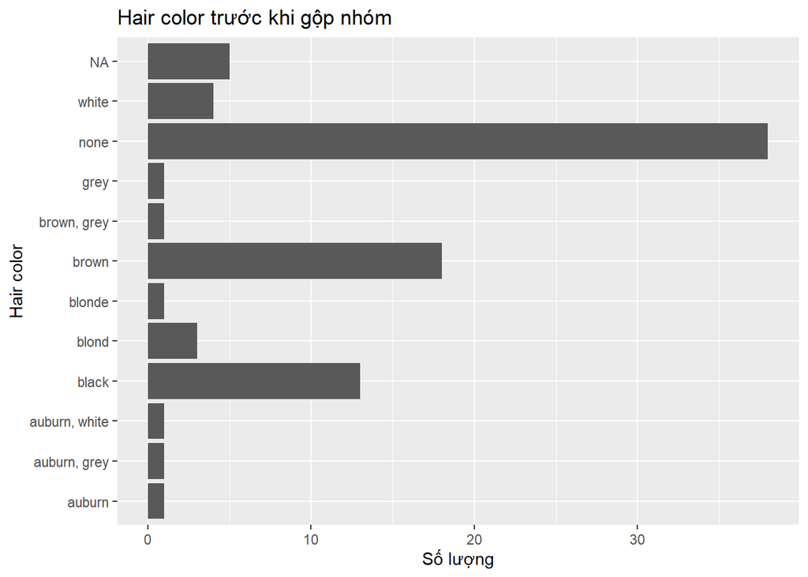

```r
ggplot(starwars, aes(x = hair_color)) +
  geom_bar() +
  coord_flip() +
  labs(
    title = "Hair color trước khi gộp nhóm",
    x = "Hair color",
    y = "Số lượng"
  )
```

#### Sau khi gộp

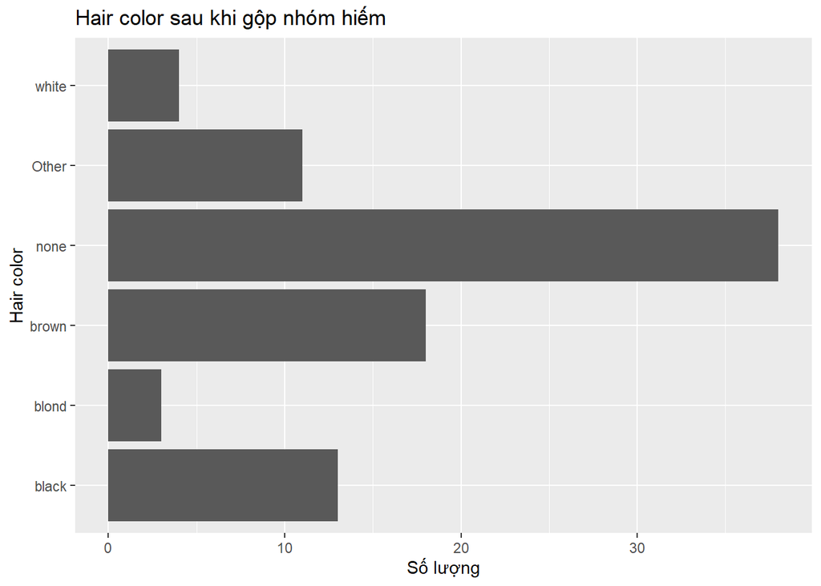

```r
ggplot(starwars_grouped, aes(x = hair_color_grouped)) +
  geom_bar() +
  coord_flip() +
  labs(
    title = "Hair color sau khi gộp nhóm hiếm",
    x = "Hair color",
    y = "Số lượng"
  )
```

Biểu đồ sau khi gộp nhóm hiếm (hair_count < 2 hoặc NA) gọn gàng và cô đọng hơn hẳn biểu đồ gốc. Việc loại bỏ các nhóm dữ liệu vụn vặt giúp làm giảm nhiễu cho biểu đồ. Nhóm nhân vật không có tóc (none) chiếm số lượng áp đảo lớn nhất với gần 38 nhân vật. Trong số các nhân vật có tóc, tóc nâu (brown) và tóc đen (black) là hai màu tóc phổ biến nhất. Các màu tóc đặc biệt hiếm gặp và các trường hợp khuyết dữ liệu đã được xử lý và gom gọn thành công vào nhóm Other (chiếm 11 nhân vật).

## 4. Câu hỏi

### 1. Chiều cao nhân vật phân phối như thế nào?

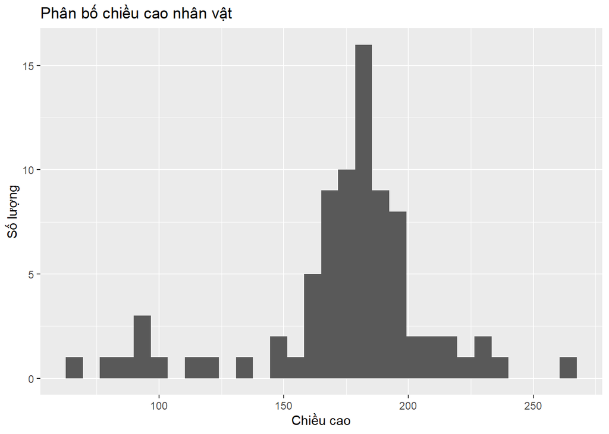

```r
ggplot(starwars, aes(x = height)) +
  geom_histogram() +
  labs(
    title = "Phân bố chiều cao nhân vật",
    x = "Chiều cao",
    y = "Số lượng"
  )
```

Biểu đồ histogram cho thấy dữ liệu chiều cao phân bố theo dạng chuẩn (hình chuông) nhưng có xu hướng lệch nhẹ và xuất hiện các giá trị dị biệt ở cả hai phía. Chiều cao của các nhân vật tập trung phổ biến nhất ở khoảng 170cm – 190cm (với đỉnh cao nhất đạt trên 15 nhân vật ở mốc ~180cm). Xuất hiện một nhóm nhỏ nhân vật có chiều cao cực thấp (dưới 100cm) và một nhân vật cá biệt có chiều cao vượt trội (trên 250cm). Chiều cao nhân vật tập trung chủ yếu ở khoảng trung bình, phần lớn nằm quanh nhóm chiều cao phổ biến của con người. Tuy nhiên vẫn có một số nhân vật có chiều cao rất thấp hoặc rất cao, làm phân phối có xuất hiện giá trị ngoại lệ.

### 2. Cân nặng có bị ảnh hưởng mạnh bởi outlier không?

#### Hình 1: Biểu đồ bị ảnh hưởng bởi Outlier (Để thang đo tự nhiên)

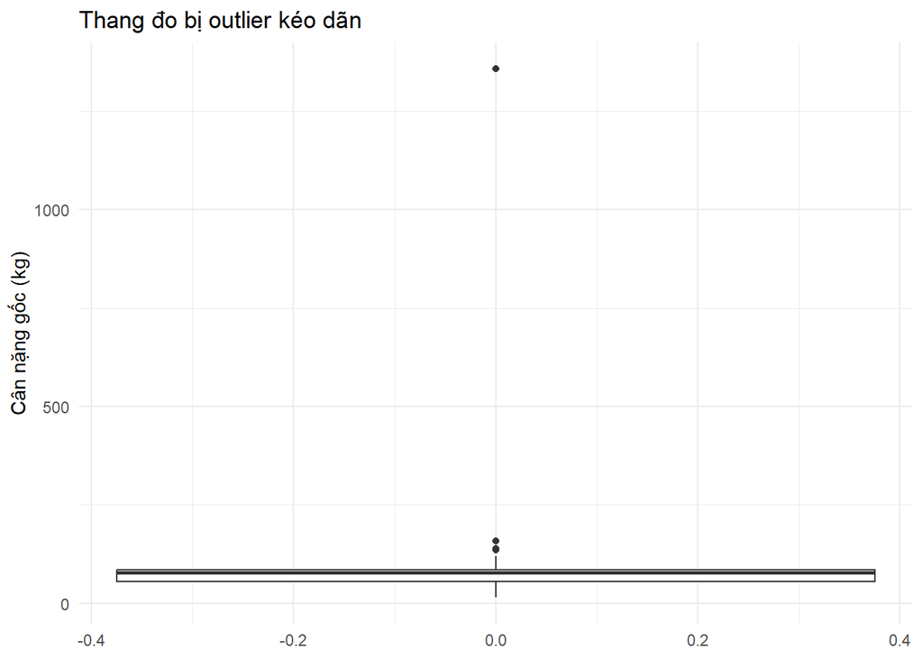

```r
p1 <- ggplot(starwars, aes(y = mass)) +
  geom_boxplot() +
  labs(
    title = "Thang đo bị outlier kéo dãn",
    y = "Cân nặng gốc (kg)"
  ) +
  theme_minimal()
p1
```

#### Hình 2: Biểu đồ sau khi giới hạn trục để nhìn rõ dữ liệu số đông

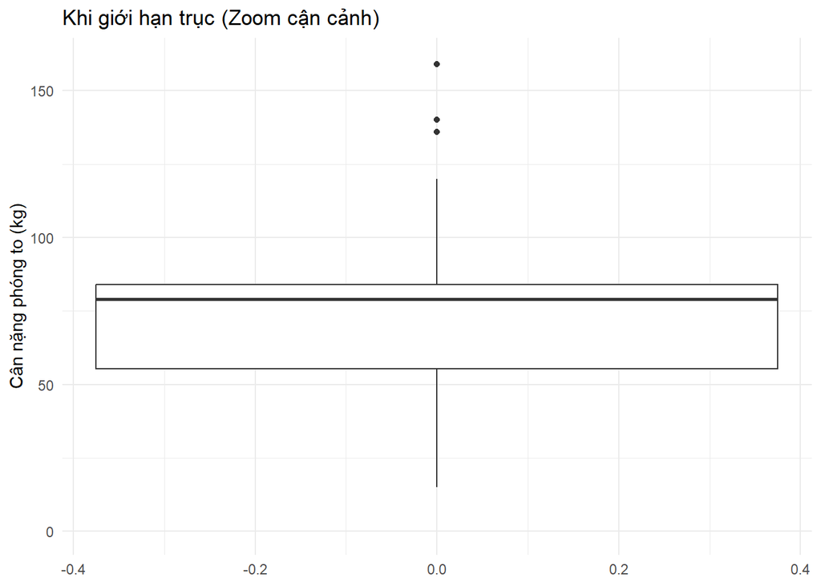

```r
p2 <- ggplot(starwars, aes(y = mass)) +
  geom_boxplot() +
  ylim(0, 160) +
  labs(
    title = "Khi giới hạn trục (Zoom cận cảnh)",
    y = "Cân nặng phóng to (kg)"
  ) +
  theme_minimal()
p2
```

Biểu đồ đối chiếu cho thấy biến cân nặng bị ảnh hưởng vô cùng nghiêm trọng bởi giá trị dị biệt (outlier). Ở biểu đồ gốc (Hình 1), sự xuất hiện của một cá thể có cân nặng đột biến (~1,358 kg) đã ép toàn bộ hộp dữ liệu của các nhân vật còn lại bẹp dí sát trục hoành, khiến người xem không thể đọc được các thông tin quan trọng như trung vị hay khoảng tứ phân vị. Ở biểu đồ đã xử lý vùng nhìn (Hình 2), khi giới hạn trục về mức 0 - 160 kg, cấu trúc phân bổ thực tế mới được lộ diện rõ ràng (trung vị khoảng 80 kg). Biến mass bị nhiễu và ảnh hưởng mạnh bởi outlier nặng ký. Trong các phân tích thống kê tiếp theo, bắt buộc phải có biện pháp loại bỏ hoặc xử lý outlier này để tránh làm lệch kết quả mô hình.

### 3. Nhóm gender nào chiếm đa số?

```r
starwars %>%
  count(gender, sort = TRUE)
```

```
## # A tibble: 3 × 2
##   gender        n
##   <chr>     <int>
## 1 masculine    66
## 2 feminine     17
## 3 <NA>          4
```

Nhóm masculine có số lượng quan sát cao nhất là nhóm chiếm đa số trong dữ liệu.

### 4. Có sự khác biệt chiều cao giữa các nhóm gender không?

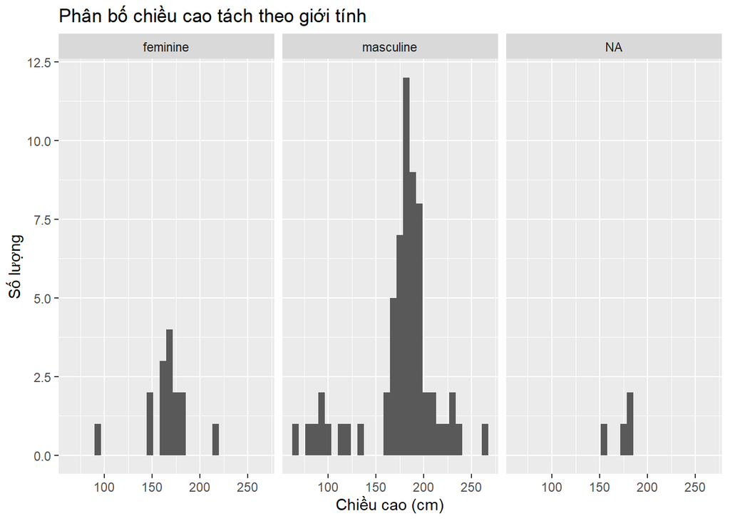

```r
ggplot(starwars, aes(x = height)) +
  geom_histogram() +
  facet_wrap(~ gender) +
  labs(
    title = "Phân bố chiều cao tách theo giới tính",
    x = "Chiều cao (cm)",
    y = "Số lượng"
  )
```

Biểu đồ Facet Histogram cho thấy rõ sự khác biệt về cả số lượng lẫn hình dáng phân bố chiều cao giữa hai giới tính. Nhóm masculine chiếm số lượng áp đảo với ngọn núi dữ liệu cao và rộng, tập trung mạnh ở khoảng 170cm – 190cm. Nhóm này cũng sở hữu dải chiều cao trải dài nhất, bao trọn các cá thể siêu lùn và khổng lồ. Nhóm feminine có số lượng ít hơn nhiều, phân bố hẹp hơn và tập trung ở phân khúc chiều cao thấp hơn, phổ biến từ 160cm – 175cm.

### 5. Có nên loại bỏ nhân vật có mass quá lớn không? Vì sao?

Không nên loại bỏ hoàn toàn trong mọi trường hợp, vì mass lớn có thể là đặc điểm thật của một số nhân vật đặc biệt. Tuy nhiên, khi phân tích xu hướng chung giữa height và mass, có thể tạo thêm phiên bản dữ liệu loại bỏ mass > 500 để biểu đồ dễ quan sát và kết quả ít bị lệch hơn.

*Kết luận bằng 5 phát hiện nổi bật*.